# R Notebook

```r
install.packages("ggdendro")
```

```r
library(tidyverse)
library(patchwork)
library(gt)
library(ggfortify)
library(ggcorrplot)
library(ggdendro)
```

Load relevant packages

```r
ncaa_lax_data <- read_csv("http://www.stat.cmu.edu/cmsac/sure/materials/data/regression_projects/womens_ncaa_lacrosse.csv")
str(ncaa_lax_data)
```

```
tibble [348 × 40] (S3: spec_tbl_df/tbl_df/tbl/data.frame)
 $ X1                : num [1:348] 1 2 3 4 5 6 7 8 9 10 ...
 $ team              : chr [1:348] "Loyola Maryland" "Denver" "Stetson" "North Carolina" ...
 $ games             : num [1:348] 21 20 17 21 21 19 16 24 19 21 ...
 $ assists           : num [1:348] 197 167 139 171 171 154 127 190 147 161 ...
 $ assists_gp        : num [1:348] 9.38 8.35 8.18 8.14 8.14 8.11 7.94 7.92 7.74 7.67 ...
 $ caused_tos        : num [1:348] 173 206 139 148 188 170 201 192 218 178 ...
 $ caused_turnover_gp: num [1:348] 8.24 10.3 8.18 7.05 8.95 ...
 $ draw_controls     : num [1:348] 313 242 234 294 358 363 236 430 246 288 ...
 $ draw_controls_gp  : num [1:348] 14.9 12.1 13.8 14 17.1 ...
 $ fouls             : num [1:348] 446 412 480 394 306 443 245 442 562 364 ...
 $ fouls_per_game    : num [1:348] 21.2 20.6 28.2 18.8 14.6 ...
 $ clears            : num [1:348] 336 342 238 338 339 293 252 334 361 362 ...
 $ clr_att           : num [1:348] 377 402 323 374 391 334 299 373 422 395 ...
 $ clr_pct           : num [1:348] 0.891 0.851 0.737 0.904 0.867 0.877 0.843 0.895 0.855 0.916 ...
 $ opp_dc            : num [1:348] 252 213 232 247 218 226 197 257 277 225 ...
 $ drawc_control_pct : num [1:348] 0.554 0.532 0.502 0.543 0.622 0.616 0.545 0.626 0.47 0.561 ...
 $ freepos_goals     : num [1:348] 40 48 18 51 51 43 37 72 30 59 ...
 $ freepos_shots     : num [1:348] 92 124 64 117 123 110 77 157 80 110 ...
 $ free_position_pct : num [1:348] 0.435 0.387 0.281 0.436 0.415 0.391 0.481 0.459 0.375 0.536 ...
 $ ground_balls      : num [1:348] 335 373 326 308 378 378 354 377 404 352 ...
 $ ground_balls_gp   : num [1:348] 15.9 18.6 19.2 14.7 18 ...
 $ goals             : num [1:348] 333 274 200 319 323 332 229 404 265 310 ...
 $ points            : num [1:348] 530 441 339 490 494 486 356 594 412 471 ...
 $ points_gp         : num [1:348] 25.2 22.1 19.9 23.3 23.5 ...
 $ team_min          : num [1:348] 1260 1210 1023 1274 1260 ...
 $ goals_allowed     : num [1:348] 191 146 247 181 221 235 181 245 226 167 ...
 $ saves             : num [1:348] 179 120 153 210 132 173 110 213 166 144 ...
 $ sv_pct            : num [1:348] 0.484 0.451 0.383 0.537 0.374 0.424 0.378 0.465 0.423 0.463 ...
 $ ga_gp             : num [1:348] 9.1 7.3 14.53 8.62 10.52 ...
 $ margin            : num [1:348] 6.76 6.4 -2.76 6.57 4.86 5.11 3 6.63 2.05 6.81 ...
 $ gf_gp             : num [1:348] 15.9 13.7 11.8 15.2 15.4 ...
 $ sog               : num [1:348] 512 450 348 507 528 546 398 617 479 530 ...
 $ sog_gp            : num [1:348] 24.4 22.5 20.5 24.1 25.1 ...
 $ turnovers         : num [1:348] 287 303 331 232 303 315 242 332 336 261 ...
 $ turnovers_gp      : num [1:348] 13.7 15.2 19.5 11.1 14.4 ...
 $ won               : num [1:348] 16 16 4 17 16 15 10 22 11 16 ...
 $ lost              : num [1:348] 5 4 13 4 5 4 6 2 8 5 ...
 $ win_pct           : num [1:348] 0.762 0.8 0.235 0.81 0.762 0.789 0.625 0.917 0.579 0.762 ...
 $ yellow_cards      : num [1:348] 44 50 34 38 21 30 17 43 43 41 ...
```

[output cut: 29 more lines]

[output not shown]

Read in data for project

```r
filtered_lax_data <- ncaa_lax_data %>%
  filter(!is.na(win_pct))
```

Filter out NA values for win pct

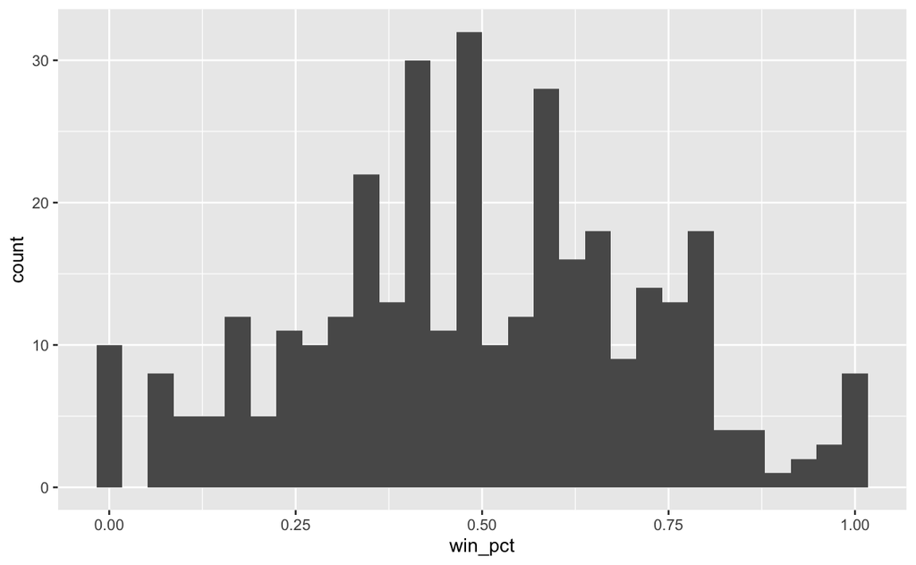

```r
filtered_lax_data %>%
  ggplot(aes(x = win_pct)) +
  geom_histogram()
```

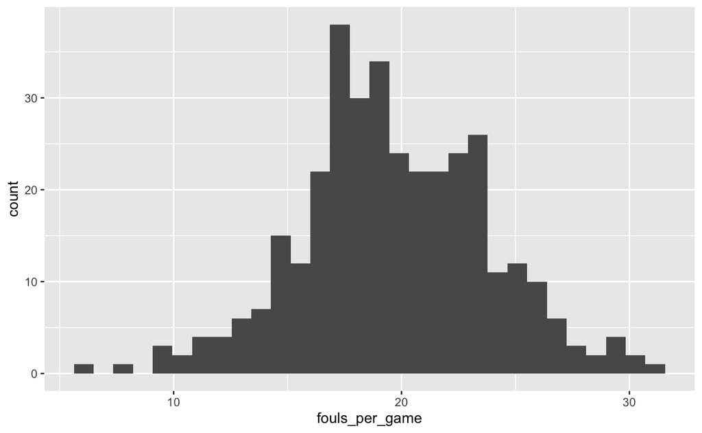

```r
ncaa_lax_data %>%
  ggplot(aes(x = fouls_per_game)) +
  geom_histogram()
```

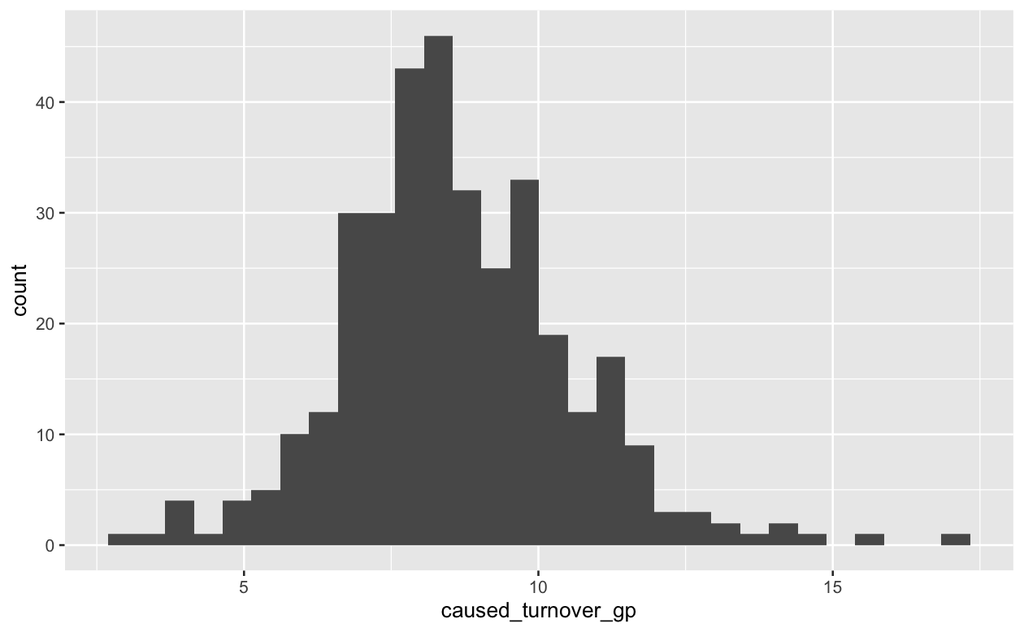

```r
ncaa_lax_data %>%
  ggplot(aes(x = caused_turnover_gp)) +
  geom_histogram()
```

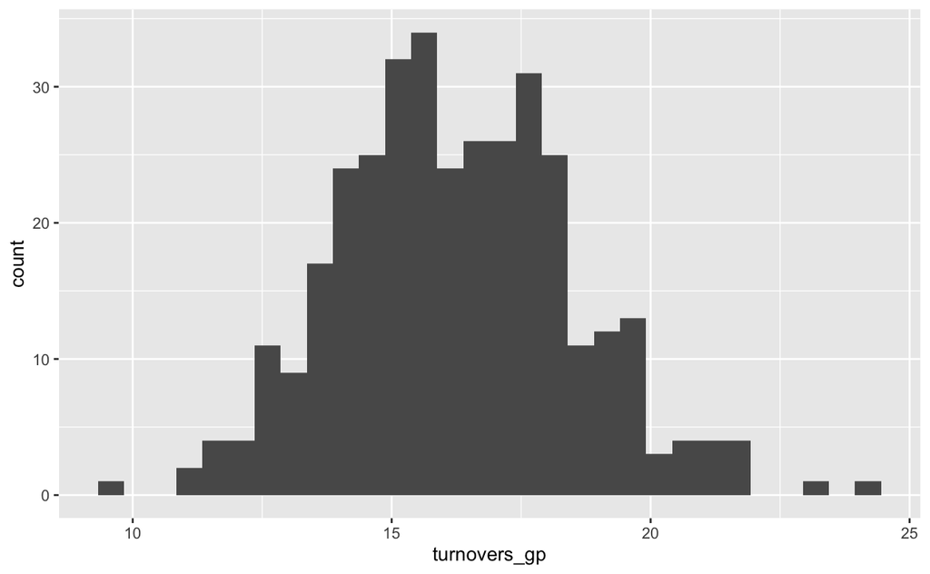

```r
ncaa_lax_data %>%
  ggplot(aes(x = turnovers_gp)) +
  geom_histogram()
```

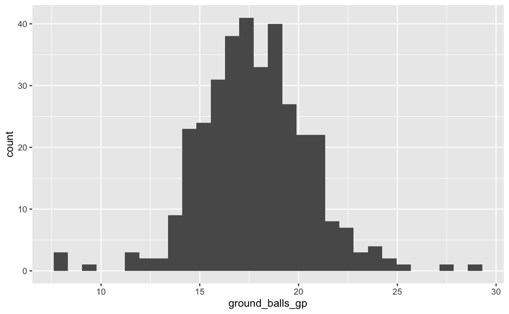

```r
ncaa_lax_data %>%
  ggplot(aes(x = ground_balls_gp)) +
  geom_histogram()
```

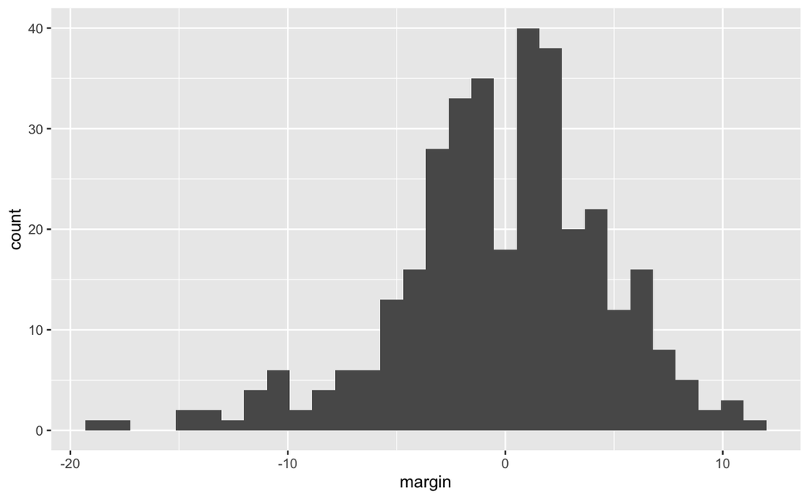

```r
ncaa_lax_data %>%
  ggplot(aes(x = margin)) +
  geom_histogram()
```

EDA looking at possible response variables. Win percent looks fairly normal but worried about getting predicted values out of the possible 0-1 range. Also interested in using margin but seems to possibly be bimodal, needs looked into further.

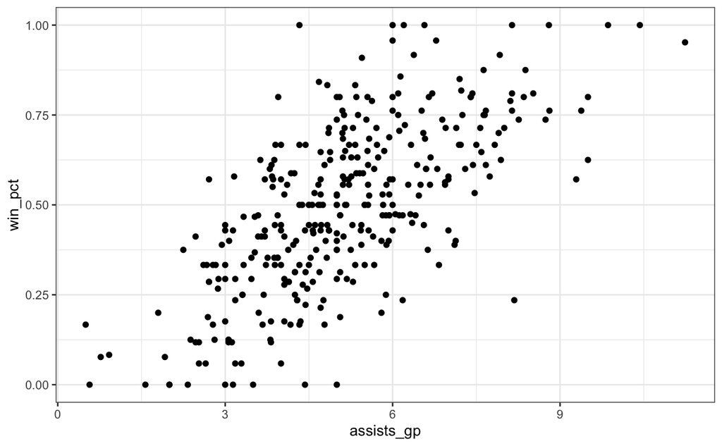

```r
filtered_lax_data %>%
  ggplot(aes(x = assists_gp, y= win_pct)) +
  geom_point() +
  theme_bw()
```

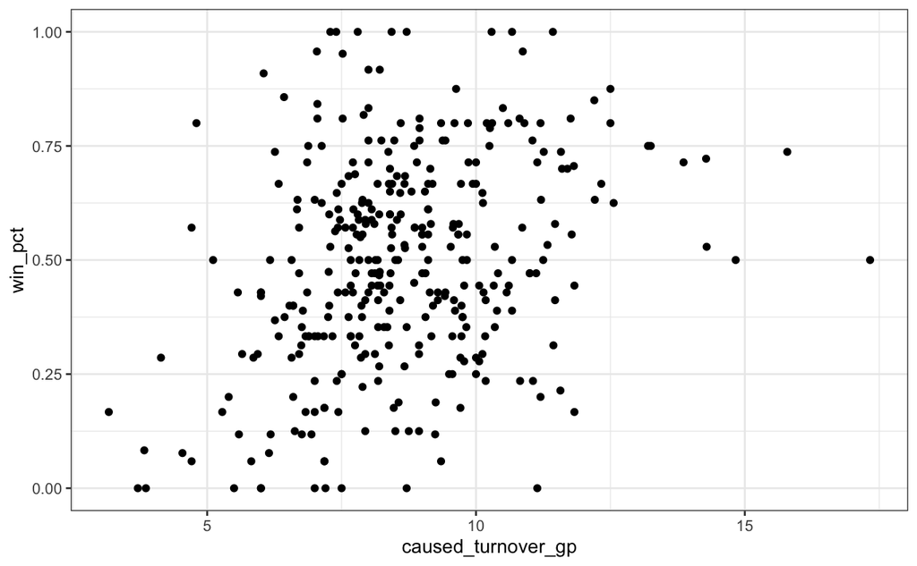

```r
filtered_lax_data %>%
  ggplot(aes(x = caused_turnover_gp, y= win_pct)) +
  geom_point() +
  theme_bw()
```

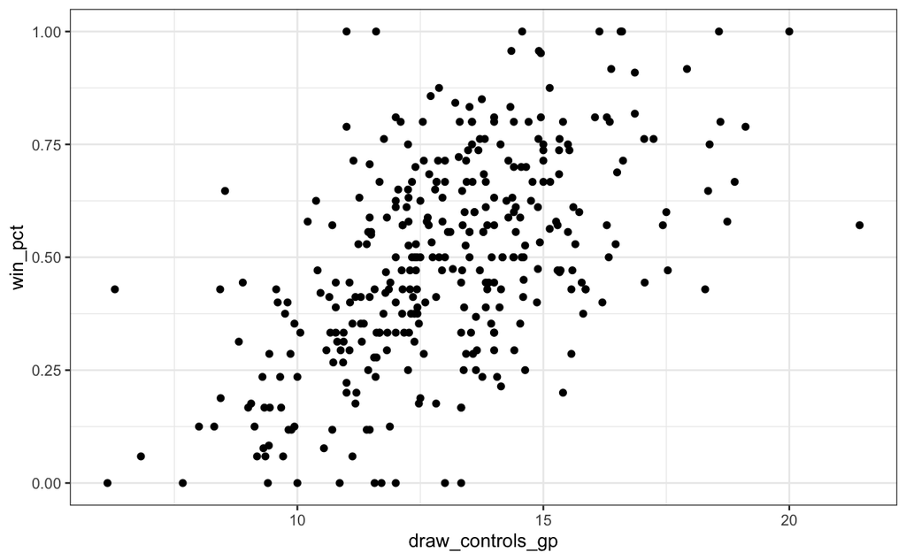

```r
filtered_lax_data %>%
  ggplot(aes(x = draw_controls_gp, y= win_pct)) +
  geom_point() +
  theme_bw()
```

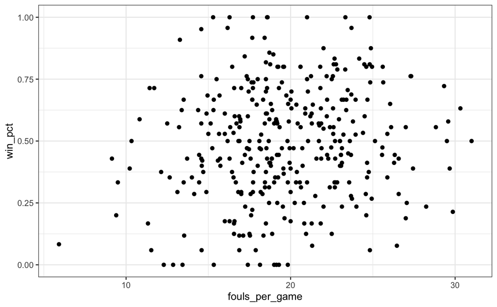

```r
filtered_lax_data %>%
  ggplot(aes(x = fouls_per_game, y= win_pct)) +
  geom_point() +
  theme_bw()
```

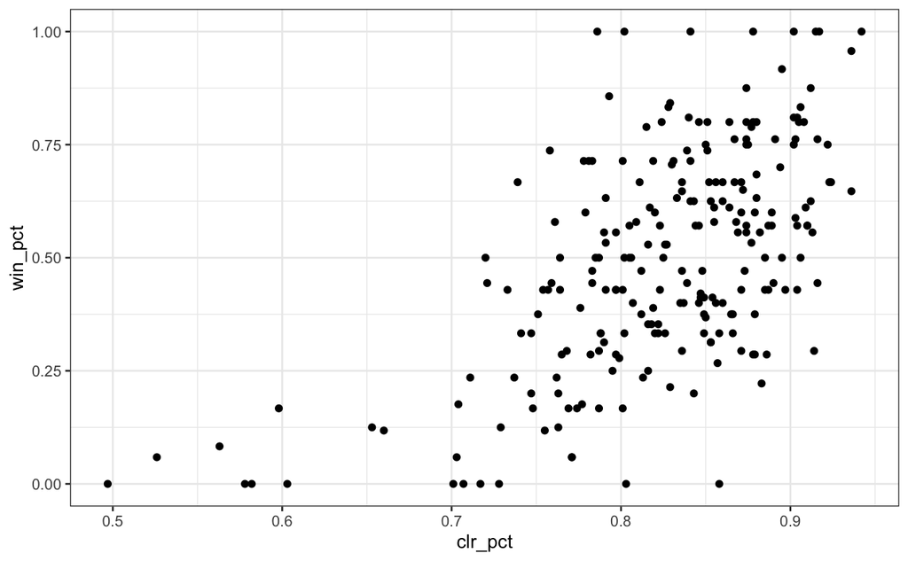

```r
filtered_lax_data %>%
  ggplot(aes(x = clr_pct, y= win_pct)) +
  geom_point() +
  theme_bw()
```

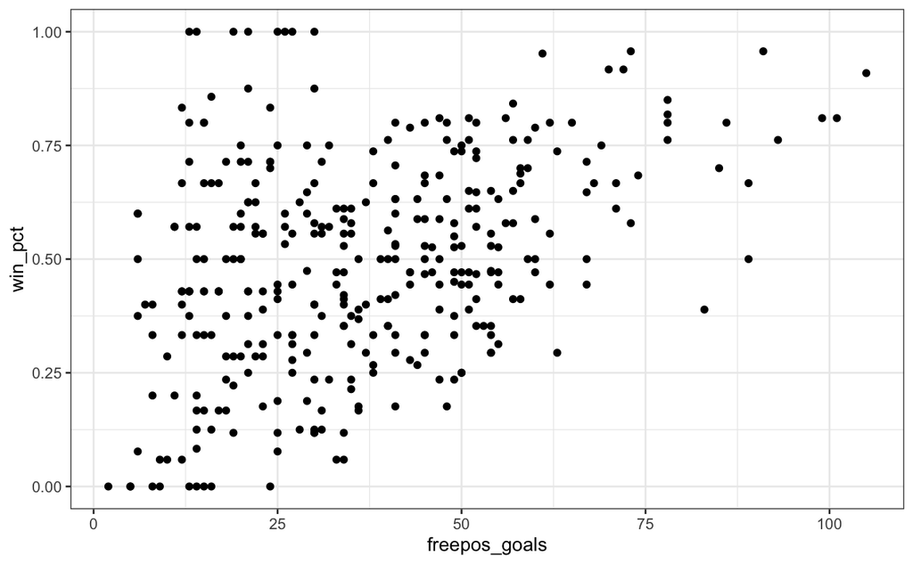

```r
filtered_lax_data %>%
  ggplot(aes(x = freepos_goals, y= win_pct)) +
  geom_point() +
  theme_bw()
```

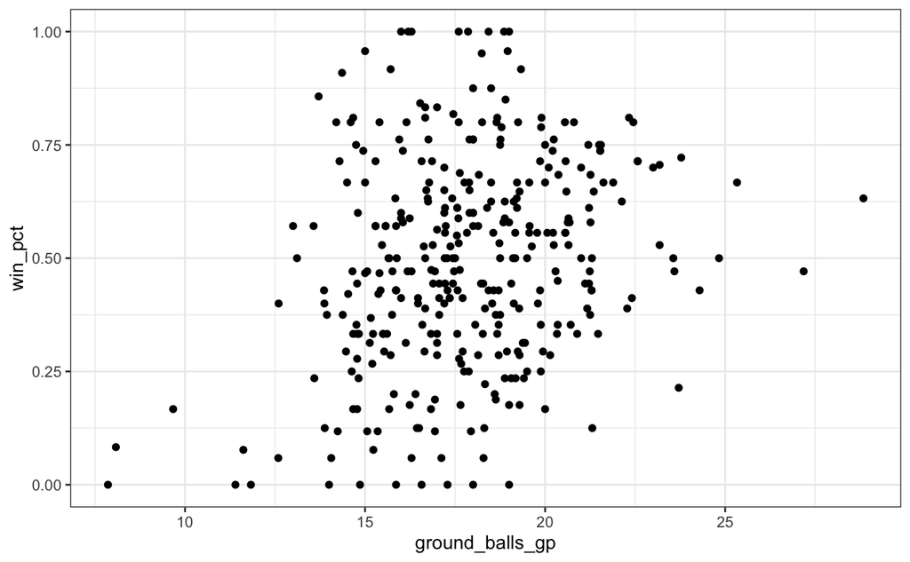

```r
filtered_lax_data %>%
  ggplot(aes(x = ground_balls_gp, y= win_pct)) +
  geom_point() +
  theme_bw()
```

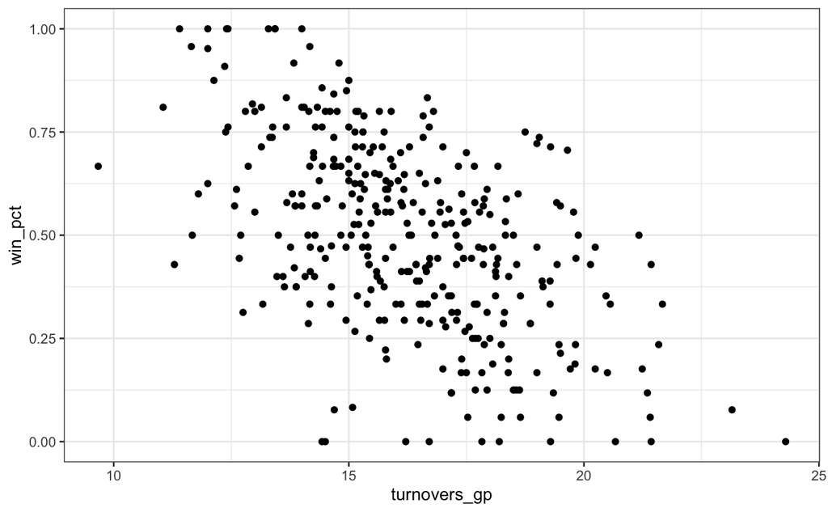

```r
filtered_lax_data %>%
  ggplot(aes(x = turnovers_gp, y= win_pct)) +
  geom_point() +
  theme_bw()
```

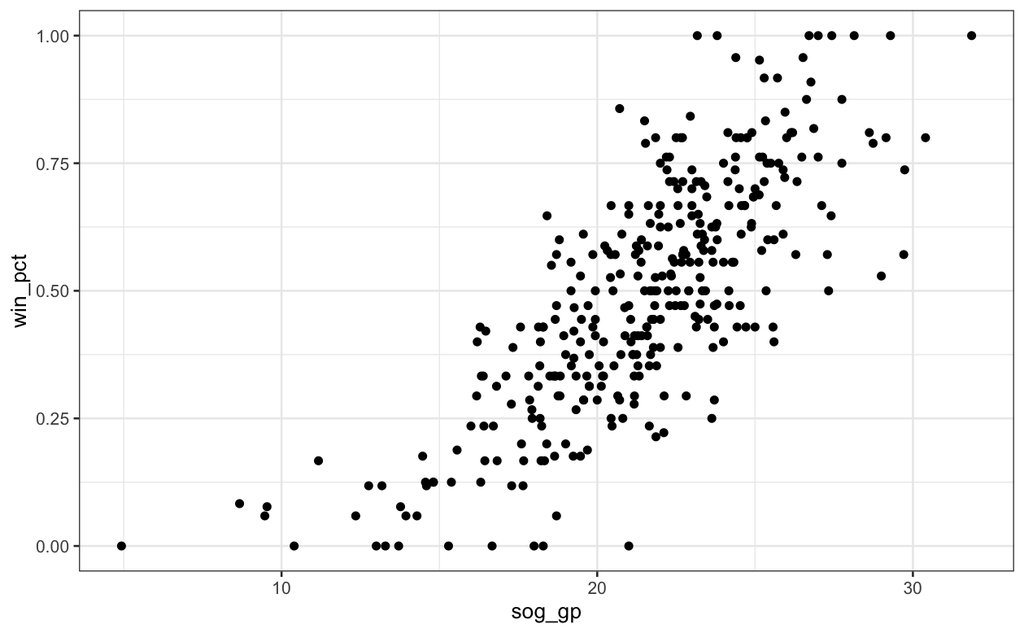

```r
filtered_lax_data %>%
  ggplot(aes(x = sog_gp, y= win_pct)) +
  geom_point() +
  theme_bw()
```

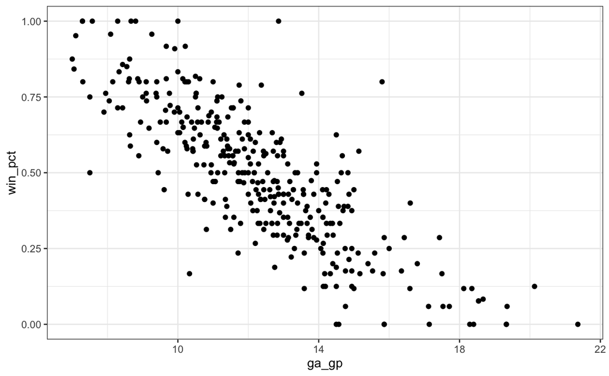

```r
filtered_lax_data %>%
  ggplot(aes(x = ga_gp, y= win_pct)) +
  geom_point() +
  theme_bw()
```

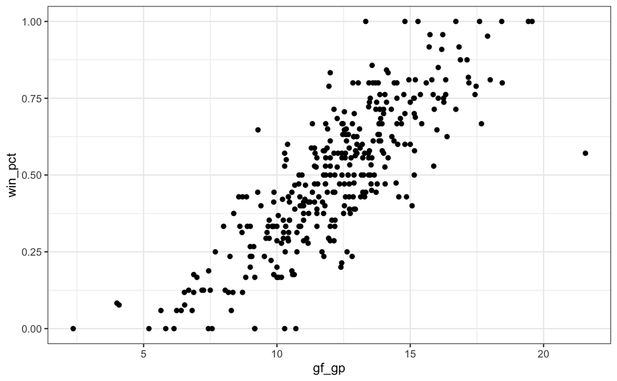

```r
filtered_lax_data %>%
  ggplot(aes(x = gf_gp, y= win_pct)) +
  geom_point() +
  theme_bw()
```

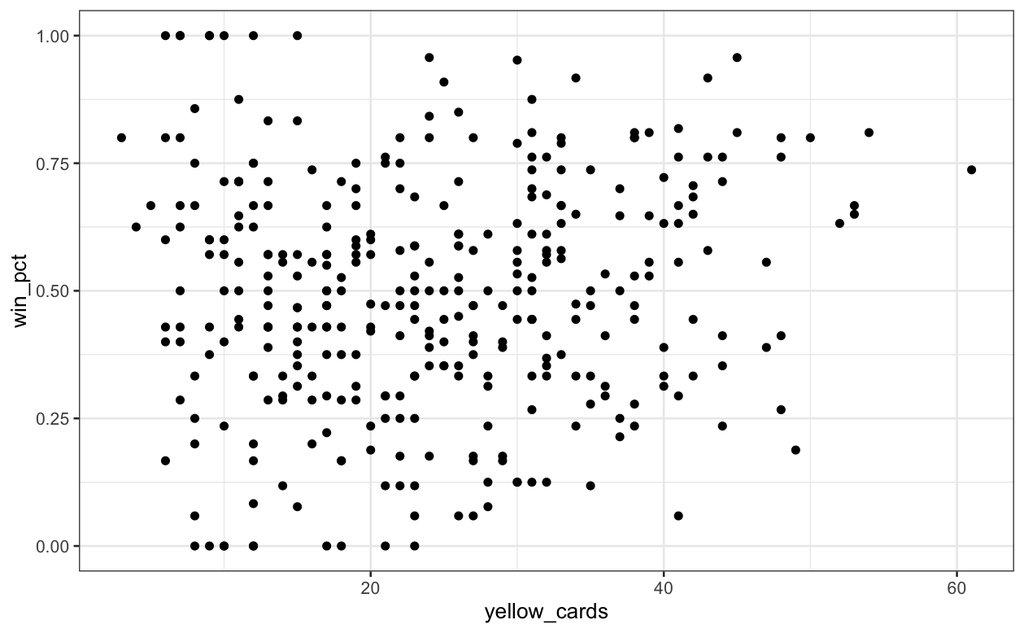

```r
filtered_lax_data %>%
  ggplot(aes(x = yellow_cards, y= win_pct)) +
  geom_point() +
  theme_bw()
```

Looked into per game variables to examine correlation between them and win percentage as the response variable. Goals for and against most strongly correlated which seems to be an obvious inference. Correlation also seen with assists_gp, draw_controls_gp, and turnovers_gp.

```r
init_lm <-
  lm(win_pct ~ gf_gp, data = filtered_lax_data)
summary(init_lm)
```

```
Call:
lm(formula = win_pct ~ gf_gp, data = filtered_lax_data)

Residuals:
     Min       1Q   Median       3Q      Max
-0.57371 -0.07637 -0.00032  0.08162  0.42581

Coefficients:
             Estimate Std. Error t value Pr(>|t|)
(Intercept) -0.348745   0.031781  -10.97   <2e-16 ***
gf_gp        0.069238   0.002551   27.14   <2e-16 ***
---
Signif. codes:
0 ‘***’ 0.001 ‘**’ 0.01 ‘*’ 0.05 ‘.’ 0.1 ‘ ’ 1

Residual standard error: 0.1305 on 344 degrees of freedom
Multiple R-squared:  0.6817,    Adjusted R-squared:  0.6808
F-statistic: 736.8 on 1 and 344 DF,  p-value: < 2.2e-16
```

```r
init_lm$fitted.values
```

[output not shown]

[output cut: 85 more lines]

[output not shown]